# Problem Statement

#### Observations:

- As observed before there is much variability in `Cost of Trip` as the `Population` increase
- Although there is more variability with `Profit` and `Price Charged` it does not always increase with `Population`
- The two cities with the least `Profit` and `Price Charged` are the second least populated and the second highest populated cities in the data
- The trend is negative for second(2nd) to the fifth(5th) most populated cities in the data

```python
# Creating a categories of age groups

# Create a list of age groups
bins = [0, 30, 40, 50, 60, np.inf]
labels = ['<30', '30-39', '40-49', '50-59', '60+']

# Convert the age column to a categorical column
xf['age_group'] = pd.cut(xf['Age'], bins=bins, labels=labels)

xf.head(2)
```

|  | Transaction ID | Date of Travel | Company | City | KM Travelled | Price Charged | Cost of Trip | Population | Users | Customer ID | Payment_Mode | Gender | Age | Income (USD/Month) | Icon | Holiday | Profit | age_group |
| --- | --- | --- | --- | --- | --- | --- | --- | --- | --- | --- | --- | --- | --- | --- | --- | --- | --- | --- |
| 0 | 10000011 | 2016-01-08 | Pink Cab | ATLANTA GA | 30.45 | 370.95 | 313.63 | 814885 | 24701 | 29290 | Card | Male | 28 | 10813 | rain | No Holiday | 57.31 | <30 |
| 1 | 10000012 | 2016-01-06 | Pink Cab | ATLANTA GA | 28.62 | 358.52 | 334.85 | 814885 | 24701 | 27703 | Card | Male | 27 | 9237 | partly-cloudy-day | No Holiday | 23.67 | <30 |

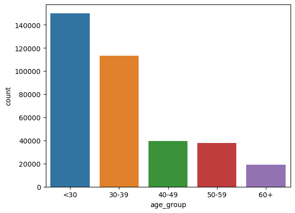

```python
sns.countplot(data=xf, x='age_group')
```

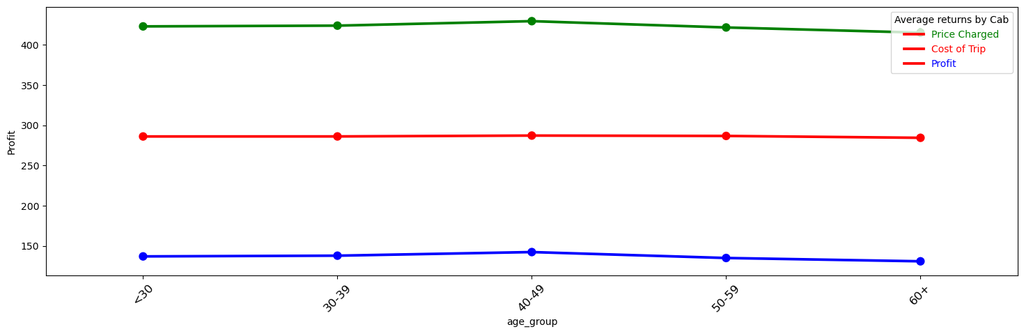

```python
# Average cost, price and profit by age group

plt.figure(figsize=(18,5));

sns.pointplot(data=xf, x='age_group', y='Cost of Trip', color='red')

sns.pointplot(data=xf, x='age_group', y='Price Charged', color='green')

sns.pointplot(data=xf, x='age_group', y='Profit', color='blue')

plt.legend(loc='best', title='Average returns by Cab', labels=['Price Charged', 'Cost of Trip', 'Profit'],
           labelcolor=['green', 'red', 'blue'])

plt.xticks(rotation=45, fontsize=12)

plt.show();
```

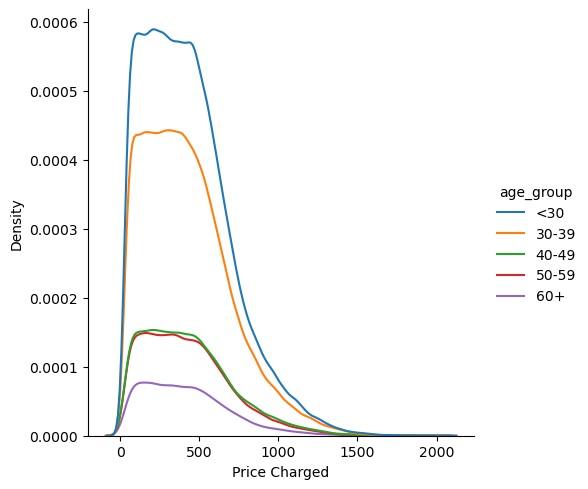

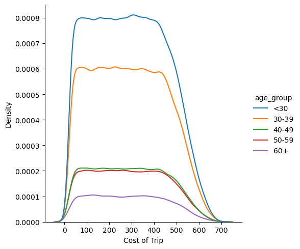

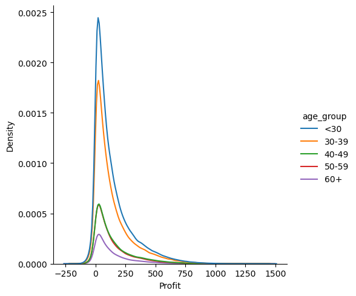

```python
plt.figure(figsize=(10,5));

sns.displot(data=xf,x='Price Charged', kind='kde', hue='age_group')

sns.displot(data=xf,x='Cost of Trip', kind='kde', hue='age_group')

sns.displot(data=xf,x='Profit', kind='kde', hue='age_group')

plt.show();
```

#### Observation:

- There is no difference in pattern across the age groups in the pointplot
- And the overall pattern in terms of volume by age group for each feature is as observed in the univariate analysis. The bulk of the transactions are conducted by customers below 40 years of age

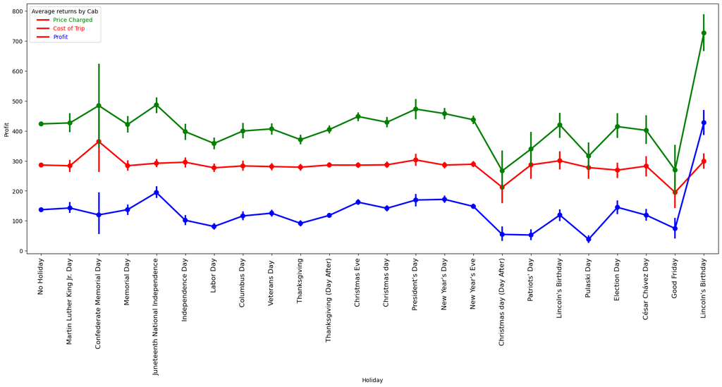

```python
# Average cost, price and profit by Holiday

plt.figure(figsize=(22,8));

sns.pointplot(data=xf, x='Holiday', y='Cost of Trip', color='red')

sns.pointplot(data=xf, x='Holiday', y='Price Charged', color='green')

sns.pointplot(data=xf, x='Holiday', y='Profit', color='blue')

plt.legend(loc='best', title='Average returns by Cab', labels=['Price Charged', 'Cost of Trip', 'Profit'],
           labelcolor=['green', 'red', 'blue'])

plt.xticks(rotation=90, fontsize=12)

plt.show();
```

#### Observations:

```python
# To identify the varying entries of the holiday Lincoln's Birthday
xf[xf['Holiday'].str.contains("Lincoln's Birthday")]['Holiday'].value_counts()
```

```
Lincoln's Birthday     186
 Lincoln's Birthday    133
Name: Holiday, dtype: int64
```

```python
# To identify the different entry of "Lincoln's Birthday"
xf[(xf['Holiday'].str.contains("Lincoln's Birthday"))&(xf['Holiday']!="Lincoln's Birthday")]['Holiday'].unique().tolist()
```

```
["\xa0Lincoln's Birthday"]
```

```python
# To replace the error entry with the correct entry
xf = xf.replace({"\xa0Lincoln's Birthday": "Lincoln's Birthday"})
```

```python
# To check the value counts of the entries of the holiday Lincoln's Birthday
xf[xf['Holiday'].str.contains("Lincoln's Birthday")]['Holiday'].value_counts()
```

```
Lincoln's Birthday    319
Name: Holiday, dtype: int64
```

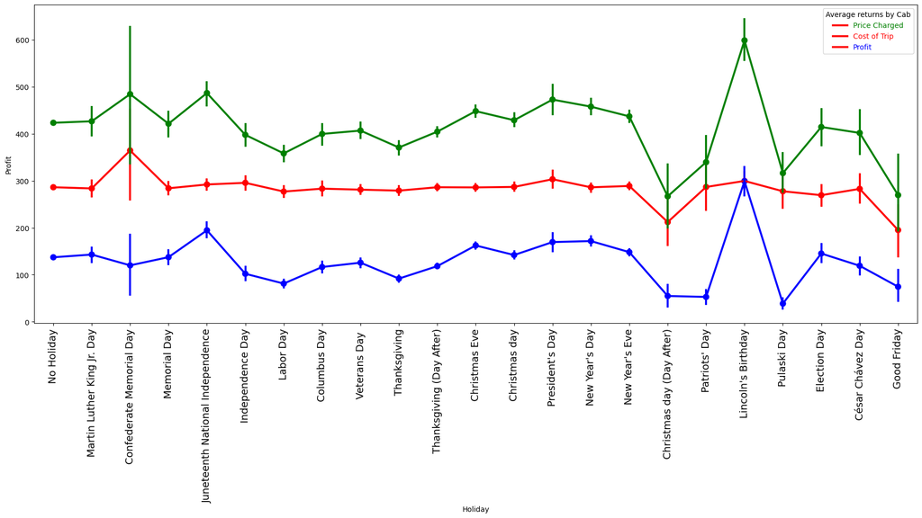

```python
# Average cost, price and profit by Holiday

plt.figure(figsize=(22,8))

sns.pointplot(data=xf, x='Holiday', y='Cost of Trip', color='red')

sns.pointplot(data=xf, x='Holiday', y='Price Charged', color='green')

sns.pointplot(data=xf, x='Holiday', y='Profit', color='blue')

plt.legend(loc='best', title='Average returns by Cab', labels=['Price Charged', 'Cost of Trip', 'Profit'],
           labelcolor=['green', 'red', 'blue'])

plt.xticks(rotation=90, fontsize=14)

plt.show();
```

#### Observations:

- After the entry correction *Lincoln's Birthday* is still the most profitable and generates the highest average price charged
- Other observations remain unchanged

```python
# Gender analysis
profit_by_gender = pd.DataFrame(data=xf.groupby('Gender', as_index=True).sum()[['Profit']].sort_values('Profit', ascending=False).reset_index())
profit_by_gender
```

|  | Gender | Profit |
| --- | --- | --- |
| 0 | Male | 28865751.15 |
| 1 | Female | 20461950.34 |

```
Male     0.57
Female   0.43
Name: Gender, dtype: float64
```

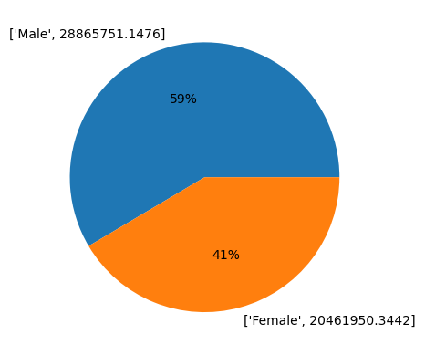

```python
# Profit by Gender analysis
keys = profit_by_gender.values.tolist()

plt.pie(profit_by_gender['Profit'], labels=keys, autopct='%.0f%%')

print(xf['Gender'].value_counts(normalize=True))
plt.show()
```

#### Observations:

- Males generate slightly higher percentage of the profit than thier population proportion
- More data is needed to measure the significance of this difference

```python
# Age-group/profit analysis analysis
profit_by_agegrp = pd.DataFrame(data=xf.groupby('age_group', as_index=True).sum()[['Profit']].sort_values('Profit', ascending=False).reset_index())
profit_by_agegrp
```

|  | age_group | Profit |
| --- | --- | --- |
| 0 | <30 | 20539909.88 |
| 1 | 30-39 | 15587448.55 |
| 2 | 40-49 | 5630551.76 |
| 3 | 50-59 | 5096253.22 |
| 4 | 60+ | 2473538.08 |

```
<30     0.42
30-39   0.31
40-49   0.11
50-59   0.11
60+     0.05
Name: age_group, dtype: float64
```

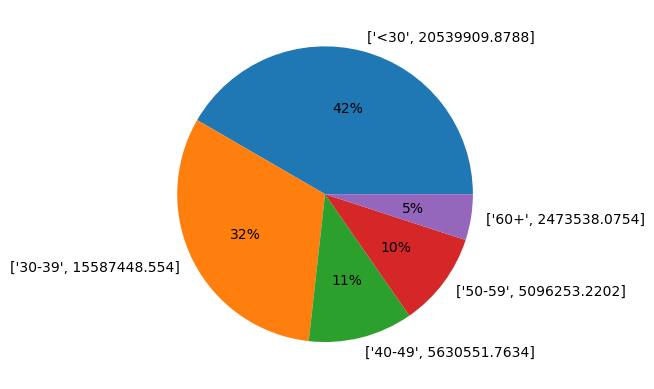

```python
# Profit by Age group analysis
keys = profit_by_agegrp.values.tolist()

plt.pie(profit_by_agegrp['Profit'], labels=keys, autopct='%.0f%%')

print(xf['age_group'].value_counts(normalize=True))
plt.show()
```

#### Observations:

- There is no significanct effect of age demographics on profit

```python
# Calculating the high whisker of boxplot of Profit

q25 = np.percentile(xf['Profit'], 25)

q75 = np.percentile(xf['Profit'], 75)

iqr = q75 - q25

high_whisker = q75 + 1.5 * iqr

print(round(high_whisker,2))
```

```
433.06
```

```python
# Gender analysis of highly profitable transactions

print(xf['Gender'].value_counts(normalize=True)*100)
xf[xf['Profit']>high_whisker]['Gender'].value_counts(normalize=True)*100
```

```
Male     57.29
Female   42.71
Name: Gender, dtype: float64
```

```
Male     60.48
Female   39.52
Name: Gender, dtype: float64
```

#### Observations:

- There is a higher likelihood of men conducting a high profit transaction

```python
# City analysis of highly profitable transactions

print(xf['City'].value_counts(normalize=True)*100)
xf[xf['Profit']>high_whisker]['City'].value_counts(normalize=True)*100
```

```
NEW YORK NY      27.79
CHICAGO IL       15.76
LOS ANGELES CA   13.37
WASHINGTON DC    12.17
BOSTON MA         8.26
SAN DIEGO CA      5.70
SILICON VALLEY    2.37
SEATTLE WA        2.23
ATLANTA GA        2.10
DALLAS TX         1.95
MIAMI FL          1.80
AUSTIN TX         1.36
ORANGE COUNTY     1.11
DENVER CO         1.06
NASHVILLE TN      0.84
SACRAMENTO CA     0.66
PHOENIX AZ        0.57
TUCSON AZ         0.54
PITTSBURGH PA     0.37
Name: City, dtype: float64
```

```
NEW YORK NY      90.55
DALLAS TX         1.90
LOS ANGELES CA    1.65
SILICON VALLEY    1.65
MIAMI FL          0.69
ORANGE COUNTY     0.59
ATLANTA GA        0.51
WASHINGTON DC     0.49
CHICAGO IL        0.47
DENVER CO         0.35
AUSTIN TX         0.34
SAN DIEGO CA      0.21
SEATTLE WA        0.17
PHOENIX AZ        0.14
PITTSBURGH PA     0.08
BOSTON MA         0.06
TUCSON AZ         0.06
SACRAMENTO CA     0.05
NASHVILLE TN      0.04
Name: City, dtype: float64
```

#### Observations:

- 90% of high profit transactions are conducted in *NEW YORK NY*
- *NEW YORK NY* is responsible for 28% of all transactions

```python
# Analysis of KM Travelled by highly profitable transactions

print(f'Observations:')
print(f'The average of all distances travelled is {round(xf["KM Travelled"].mean(),2)}km')
print(f'The average distance travelled with high profit is {round(xf[xf["Profit"]>high_whisker]["KM Travelled"].mean(),2)}km')
print(f'The average distance travelled in NEW YORK NY is {round(xf[xf["City"]=="NEW YORK NY"]["KM Travelled"].mean(),2)}km')
```

```
Observations:
The average of all distances travelled is 22.57km
The average distance travelled with high profit is 35.67km
The average distance travelled in NEW YORK NY is 22.51km
```

```python
# Analysis of age demographic of high profit transactions users

print(f'The age demographic breakdown for all transactions is as follows:')
print(xf["age_group"].value_counts(normalize=True)*100)
print('-' * 50)
print(f'The age demographic breakdown for high profit transactions is as follows:')
print(xf[xf["Profit"]>high_whisker]["age_group"].value_counts(normalize=True)*100)
```

```
The age demographic breakdown for all transactions is as follows:
<30     41.75
30-39   31.47
40-49   11.01
50-59   10.51
60+      5.26
Name: age_group, dtype: float64
--------------------------------------------------
The age demographic breakdown for high profit transactions is as follows:
<30     41.46
30-39   31.87
40-49   12.01
50-59    9.98
60+      4.68
Name: age_group, dtype: float64
```

#### Observations:

- There is no significant difference between the age demographic breakdown of all transactions and high profit transactions

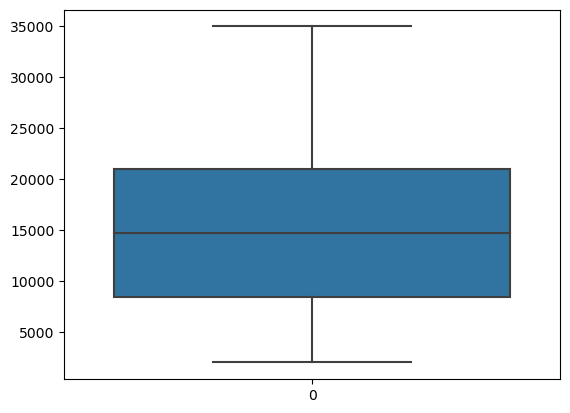

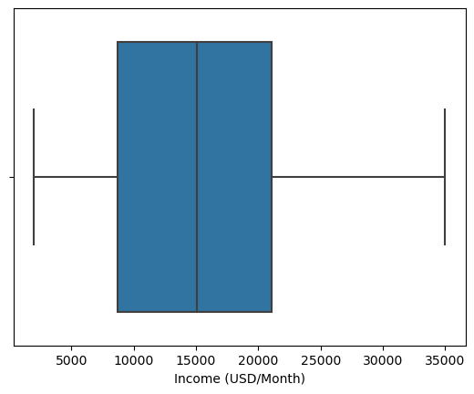

```python
# Comparison of income distribution of high profit users and all users

sns.boxplot(xf['Income (USD/Month)'])
plt.show()

sns.boxplot(data=xf[xf["Profit"]>high_whisker], x='Income (USD/Month)');
```

#### Observations:

- The income distribution is similar both high profit transacions and all transactions

```python
# Comparison of payment mode of high profit transactions and all transactions

print(xf['Payment_Mode'].value_counts(normalize=True)*100)
print('-' * 50)
xf[xf["Profit"]>high_whisker]['Payment_Mode'].value_counts(normalize=True)*100
```

```
Card   59.96
Cash   40.04
Name: Payment_Mode, dtype: float64
--------------------------------------------------
```

```
Card   59.49
Cash   40.51
Name: Payment_Mode, dtype: float64
```

#### Observations:

- The distribution of payment mode is similar in both high profit transactions and all transactions

```python
# Comparison of weather of high profit transactions and all transactions

print(xf['Icon'].value_counts(normalize=True)*100)
print('-' * 50)
xf[xf["Profit"]>high_whisker]['Icon'].value_counts(normalize=True)*100
```

```
rain                41.16
partly-cloudy-day   37.93
clear-day           15.26
snow                 3.25
cloudy               2.29
wind                 0.10
Name: Icon, dtype: float64
--------------------------------------------------
```

```
rain                56.04
partly-cloudy-day   25.59
clear-day           12.01
snow                 5.63
cloudy               0.73
wind                 0.00
Name: Icon, dtype: float64
```

```python
# Checking the prevalent weather in each city
wbc = pd.DataFrame(xf.groupby('City')['Icon'].value_counts(normalize=True)*100)
pd.set_option('display.max_rows', None)
wbc
```

| City | Icon | Icon |
| --- | --- | --- |
| ATLANTA GA | partly-cloudy-day | 47.51 |
|  | rain | 38.56 |
|  | clear-day | 12.00 |
|  | cloudy | 1.28 |
|  | snow | 0.65 |
| AUSTIN TX | partly-cloudy-day | 54.92 |
|  | rain | 27.29 |
|  | clear-day | 14.50 |
|  | cloudy | 3.29 |
| BOSTON MA | rain | 59.97 |
|  | partly-cloudy-day | 32.44 |
|  | clear-day | 3.46 |
|  | cloudy | 2.40 |
|  | snow | 1.31 |
|  | wind | 0.41 |
| CHICAGO IL | partly-cloudy-day | 45.63 |
|  | rain | 36.37 |
|  | clear-day | 7.71 |
|  | snow | 5.38 |
|  | cloudy | 4.60 |
|  | wind | 0.31 |
| DALLAS TX | partly-cloudy-day | 47.80 |
|  | rain | 34.09 |
|  | clear-day | 15.06 |
|  | cloudy | 2.65 |
|  | snow | 0.21 |
|  | wind | 0.19 |
| DENVER CO | partly-cloudy-day | 64.89 |
|  | rain | 23.35 |
|  | clear-day | 6.09 |

[output cut: 63 more lines]

#### Observations:

- Although it appears it tends to rain more for high profit transactions, that can be explained by the fact that most of such transactions are conducted in *NEW YORK NY* which experiences rain 60% of the time.

```python
# Comparison of cab company distribution of high profit transactions and all transactions

print('The distribution of cab companies in all cities is:')
print(xf['Company'].value_counts(normalize=True)*100)
print('-' * 50)
print('The distribution of cab companies for high profit transactions is:')
print(xf[xf["Profit"]>high_whisker]['Company'].value_counts(normalize=True)*100)
print('-' * 50)
print('The distribution of cab companies in NEW YORK NY is:')
xf[xf["City"]=="NEW YORK NY"]['Company'].value_counts(normalize=True)*100
```

```
The distribution of cab companies in all cities is:
Yellow Cab   76.43
Pink Cab     23.57
Name: Company, dtype: float64
--------------------------------------------------
The distribution of cab companies for high profit transactions is:
Yellow Cab   99.18
Pink Cab      0.82
Name: Company, dtype: float64
--------------------------------------------------
The distribution of cab companies in NEW YORK NY is:
```

```
Yellow Cab   86.02
Pink Cab     13.98
Name: Company, dtype: float64
```

#### Observations:

- It appears the *Yellow Cab* is especially favoured for high profit transactions as it has a near absolute (99%) proportions of all high profit transactions
- This performance is higher than *Yellow Cab's* share of business in *NEW YORK NY* where the bulk of high profit transactions are conducted

```python
# Checking the proportion of weekend transactions
xf['Weekend'] = xf['Date of Travel'].dt.weekday.isin([5, 6])

print('The proportion of weekend transactions is:')
print(xf['Weekend'].value_counts(normalize=True)*100)
print('-' * 50)
print('The proportion of high profit weekend transactions is:')
print(xf[xf["Profit"]>high_whisker]['Weekend'].value_counts(normalize=True)*100)
print('-' * 50)
print('The proportion of high profit weekend transactions in NEW YORK NY is:')
xf[xf["City"]=="NEW YORK NY"]['Weekend'].value_counts(normalize=True)*100
```

```
The proportion of weekend transactions is:
False   58.67
True    41.33
Name: Weekend, dtype: float64
--------------------------------------------------
The proportion of high profit weekend transactions is:
False   52.03
True    47.97
Name: Weekend, dtype: float64
--------------------------------------------------
The proportion of high profit weekend transactions in NEW YORK NY is:
```

```
False   58.65
True    41.35
Name: Weekend, dtype: float64
```

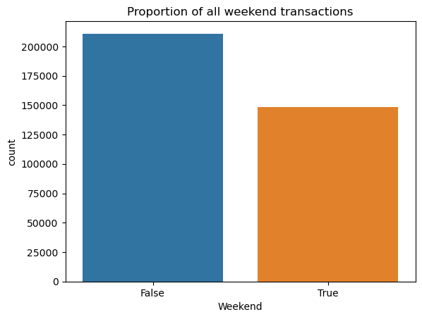

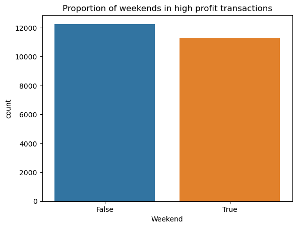

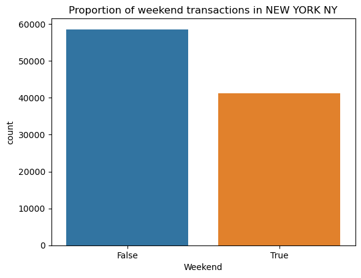

```python
# Plot of weekend transactions
sns.countplot(data=xf, x='Weekend')
plt.title("Proportion of all weekend transactions")
plt.show()

sns.countplot(data=xf[xf["Profit"]>high_whisker], x='Weekend')
plt.title("Proportion of weekends in high profit transactions")
plt.show()

sns.countplot(data=xf[xf["City"]=="NEW YORK NY"], x='Weekend')
plt.title("Proportion of weekend transactions in NEW YORK NY")
plt.show();
```

#### Observations:

- Given that the proportion of weekend days is 28.57%, the proportion of all transaction is significant at 41.33%. More transactions tend to be conducted in the 2 days of the weekend than the rest of the week
- The propotion of weekends in high profit transactions is higher still compared to all transactions at 47.97%. The chances that a high profit transaction will on a weekend is higher than for all transaction
- The weekend distribution for *NEW YORK NY* is similar to all cities. *NEW YORK NY* users do not have a higher tendency to conduct transactions on a weekend than other cities but when they do it is more likely to be of high profit

```python
# Creating year and month columns
xf['month'] = xf['Date of Travel'].dt.month_name()
xf['year'] = xf['Date of Travel'].dt.year
xf.head(2)
```

|  | Transaction ID | Date of Travel | Company | City | KM Travelled | Price Charged | Cost of Trip | Population | Users | Customer ID | ... | Gender | Age | Income (USD/Month) | Icon | Holiday | Profit | age_group | Weekend | month | year |
| --- | --- | --- | --- | --- | --- | --- | --- | --- | --- | --- | --- | --- | --- | --- | --- | --- | --- | --- | --- | --- | --- |
| 0 | 10000011 | 2016-01-08 | Pink Cab | ATLANTA GA | 30.45 | 370.95 | 313.63 | 814885 | 24701 | 29290 | ... | Male | 28 | 10813 | rain | No Holiday | 57.31 | <30 | False | January | 2016 |
| 1 | 10000012 | 2016-01-06 | Pink Cab | ATLANTA GA | 28.62 | 358.52 | 334.85 | 814885 | 24701 | 27703 | ... | Male | 27 | 9237 | partly-cloudy-day | No Holiday | 23.67 | <30 | False | January | 2016 |

2 rows × 21 columns

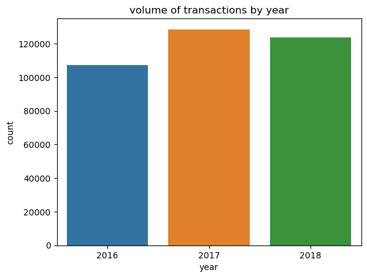

```python
# Plot of transactions volume by year
sns.countplot(data=xf, x='year')
plt.title("volume of transactions by year")
plt.show();
```

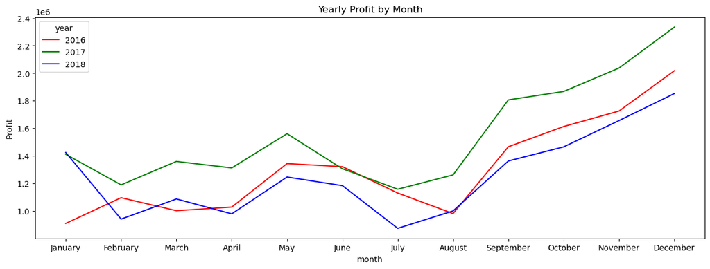

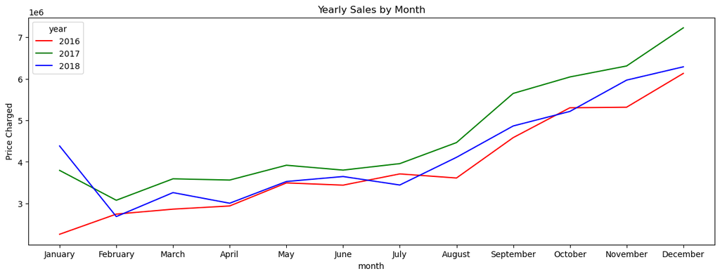

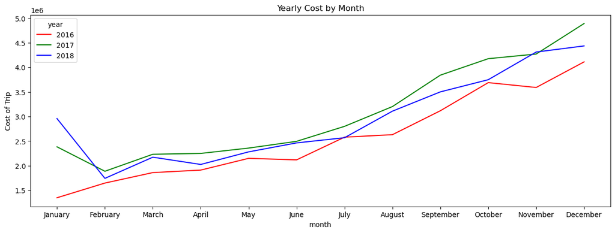

```python
# Grouping the dataframe by year and month
yearly_sales = xf.groupby(['year', 'month']).sum().reset_index()
yearly_sales['month'] = pd.Categorical(yearly_sales['month'],
                                   categories=['January', 'February', 'March', 'April',
                                               'May', 'June', 'July', 'August', 'September',
                                               'October', 'November', 'December'],
                                   ordered=True)

# Plotting yearly profit by month
plt.figure(figsize=(15, 5))
sns.lineplot(x='month', y='Profit', hue='year', data=yearly_sales, palette=['red', 'green', 'blue'])
plt.title("Yearly Profit by Month");

# Plotting yearly sales by month
plt.figure(figsize=(15, 5))
sns.lineplot(x='month', y='Price Charged', hue='year', data=yearly_sales, palette=['red', 'green', 'blue'])
plt.title("Yearly Sales by Month");

# Plotting yearly total cost by month
plt.figure(figsize=(15, 5))
sns.lineplot(x='month', y='Cost of Trip', hue='year', data=yearly_sales, palette=['red', 'green', 'blue'])
plt.title("Yearly Cost by Month");
```

#### Observations:

- The volume of transactions is highest is `2017` and lowest in `2016`
- Profit improve generally as the month approach the end of the year for each year
- Profit is highest for `2017` and lowest for `2018` despite 2018 having higher transaction volume than `2016`
- Although `2018` sales is generally at the same level as `2016` it recorded higher cost than `2016`

### Profit Transactions vs Loss Transactions analysis

```python
# Investing loss transactions

print('Observation:')
profit_trans = xf[xf['Profit']>0]
print(f'The count of profit transactions is {profit_trans.shape[0]}')

loss_trans = xf[xf['Profit']<0]
print(f'The count of loss transactions is {loss_trans.shape[0]}')
print(f'The percentage of loss transactions is {round((loss_trans.shape[0]*100)/xf.shape[0],2)}%')
```

```
Observation:
The count of profit transactions is 334569
The count of loss transactions is 24819
The percentage of loss transactions is 6.91%
```

```python
# Checking the head of the data
loss_trans.head(3)
```

|  | Transaction ID | Date of Travel | Company | City | KM Travelled | Price Charged | Cost of Trip | Population | Users | Customer ID | ... | Gender | Age | Income (USD/Month) | Icon | Holiday | Profit | age_group | Weekend | month | year |
| --- | --- | --- | --- | --- | --- | --- | --- | --- | --- | --- | --- | --- | --- | --- | --- | --- | --- | --- | --- | --- | --- |
| 150 | 10009063 | 2016-02-21 | Pink Cab | ATLANTA GA | 6.78 | 65.70 | 77.29 | 814885 | 24701 | 29525 | ... | Female | 20 | 7199 | rain | No Holiday | -11.59 | <30 | True | February | 2016 |
| 152 | 10009065 | 2016-02-20 | Pink Cab | ATLANTA GA | 4.48 | 47.93 | 48.83 | 814885 | 24701 | 28136 | ... | Male | 35 | 21085 | partly-cloudy-day | No Holiday | -0.90 | 30-39 | True | February | 2016 |
| 153 | 10009066 | 2016-02-13 | Pink Cab | ATLANTA GA | 28.75 | 316.44 | 319.12 | 814885 | 24701 | 28685 | ... | Female | 28 | 2931 | clear-day | No Holiday | -2.69 | <30 | True | February | 2016 |

3 rows × 21 columns

```python
print(f'The least distance traveld in loss transactions is {loss_trans["KM Travelled"].min()}km while the longest distance traveled is {loss_trans["KM Travelled"].max()}km')
print(f'The least distance traveld in profit transactions is {profit_trans["KM Travelled"].min()}km while the longest distance traveled is {profit_trans["KM Travelled"].max()}km')
```

```
The least distance traveld in loss transactions is 1.9km while the longest distance traveled is 48.0km
The least distance traveld in profit transactions is 1.9km while the longest distance traveled is 48.0km
```

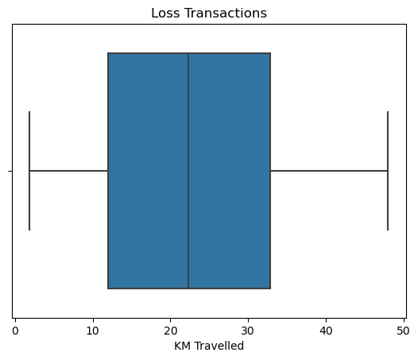

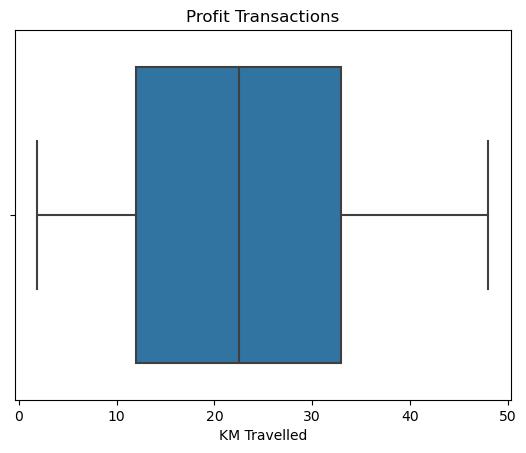

```python
# Checking the KM travelled in loss transactions vs profit transactions
sns.boxplot(data=loss_trans, x='KM Travelled')
plt.title("Loss Transactions")
plt.show()

sns.boxplot(data=profit_trans, x='KM Travelled')
plt.title("Profit Transactions");
```

#### Observation:

- Distance traveled does not appear to influence profit or loss of each transaction

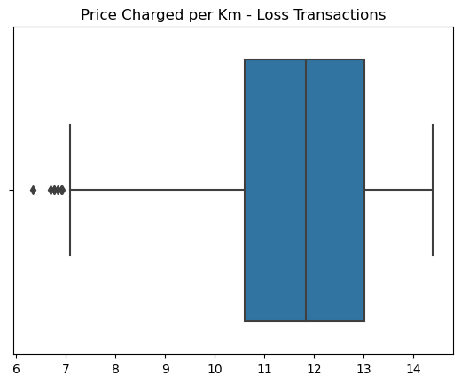

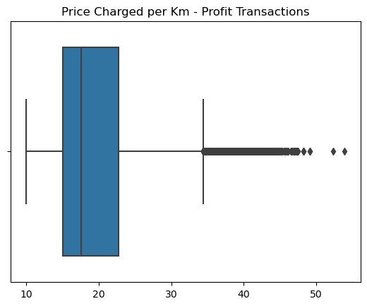

```python
# Checking the price charged per km traveled
sns.boxplot(data=loss_trans, x=loss_trans["Price Charged"]/loss_trans["KM Travelled"])
plt.title("Price Charged per Km - Loss Transactions")
plt.show()

sns.boxplot(data=profit_trans, x=profit_trans["Price Charged"]/profit_trans["KM Travelled"])
plt.title("Price Charged per Km - Profit Transactions")
plt.show()
```

#### Observations:

- Generally, the price charged per km for profit transactions are higher than loss transactions
- There is an overlap area between 10USD and 15USD where both profit and loss can result. This suggest price charged per km is not the only factor at play

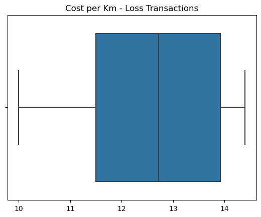

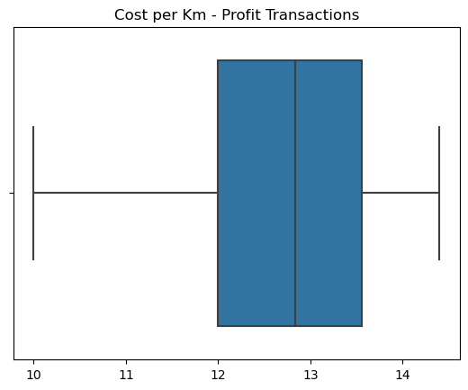

```python
# Checking the cost per km traveled
sns.boxplot(data=loss_trans, x=loss_trans["Cost of Trip"]/loss_trans["KM Travelled"])
plt.title("Cost per Km - Loss Transactions")
plt.show()

sns.boxplot(data=profit_trans, x=profit_trans["Cost of Trip"]/profit_trans["KM Travelled"])
plt.title("Cost per Km - Profit Transactions")
plt.show()
```

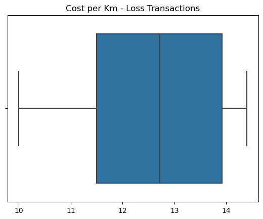

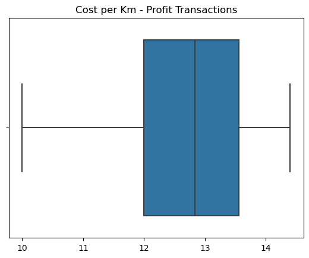

```python
# Checking the cost per km traveled
sns.boxplot(data=loss_trans, x=loss_trans["Cost of Trip"]/loss_trans["KM Travelled"], hue=loss_trans['City'])
plt.title("Cost per Km - Loss Transactions")
plt.show()

sns.boxplot(data=profit_trans, x=profit_trans["Cost of Trip"]/profit_trans["KM Travelled"], hue='City')
plt.title("Cost per Km - Profit Transactions")
plt.show()
```

#### Observations:

- Both profit and loss transactions are almost identical in their cost per km.
- There is no significant difference in the boxplots that explain a loss or profit per trip

```python
# Checking the influence of weather on profit/loss
print('Weather distribution for loss transactions')
print(loss_trans["Icon"].value_counts(normalize=True)*100)
print('-'*50)
print('Weather distribution for profit transactions')
print(profit_trans["Icon"].value_counts(normalize=True)*100)
```

```
Weather distribution for loss transactions
partly-cloudy-day   44.09
rain                36.02
clear-day           15.54
cloudy               2.64
snow                 1.55
wind                 0.16
Name: Icon, dtype: float64
--------------------------------------------------
Weather distribution for profit transactions
rain                41.54
partly-cloudy-day   37.48
clear-day           15.24
snow                 3.38
cloudy               2.27
wind                 0.10
Name: Icon, dtype: float64
```

#### Observation:

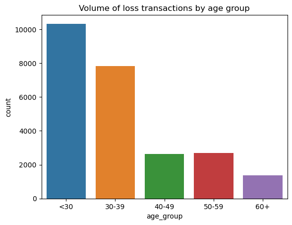

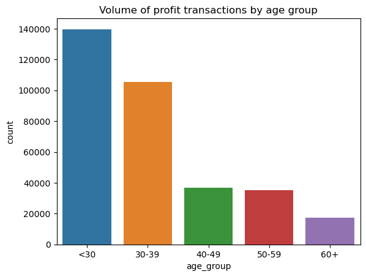

```python
# Plot of profit/loss transactions volume by age group
sns.countplot(data=loss_trans, x='age_group')
plt.title("Volume of loss transactions by age group")
plt.show()

sns.countplot(data=profit_trans, x='age_group')
plt.title("Volume of profit transactions by age group")
plt.show();
```

#### Observations:

- The distribution of pattern volume of transactions by age group for each type of transaction is similar
- There is no evidence from data that age group distribution has any effect on the type of transaction

```python
# Plot of profit/loss transactions volume by weekend
print('Observations:')
print(' ')
print('Proportion of weekend transactions - Loss transaction')
print(loss_trans["Weekend"].value_counts(normalize=True)*100)
print('-'*50)
print('Proportion of weekend transactions - Profit transactions')
print(profit_trans["Weekend"].value_counts(normalize=True)*100)
```

```
Observations:

Proportion of weekend transactions - Loss transaction
False   67.51
True    32.49
Name: Weekend, dtype: float64
--------------------------------------------------
Proportion of weekend transactions - Profit transactions
False   58.01
True    41.99
Name: Weekend, dtype: float64
```

#### Obervations:

- Profit transactions have a higher proportion of weekend transactions than loss transactions by 9.5%

```python
# Plot of profit/loss transactions volume by city
print('Observations:')
print(' ')
print('Proportion of transactions by city - Loss transaction')
print(loss_trans['City'].value_counts(normalize=True)*100)
print('-'*50)
print('Proportion of transactions by city - Profit transactions')
print(profit_trans['City'].value_counts(normalize=True)*100)
```

```
Observations:

Proportion of transactions by city - Loss transaction
CHICAGO IL       31.83
BOSTON MA        15.10
WASHINGTON DC    12.90
LOS ANGELES CA   12.20
SAN DIEGO CA      5.09
SEATTLE WA        3.32
NASHVILLE TN      2.79
DALLAS TX         2.18
SACRAMENTO CA     2.08
DENVER CO         2.01
NEW YORK NY       1.83
ATLANTA GA        1.46
MIAMI FL          1.36
PITTSBURGH PA     1.35
TUCSON AZ         1.12
PHOENIX AZ        1.00
AUSTIN TX         0.97
ORANGE COUNTY     0.93
SILICON VALLEY    0.47
Name: City, dtype: float64
--------------------------------------------------
Proportion of transactions by city - Profit transactions
NEW YORK NY      29.72
CHICAGO IL       14.56
LOS ANGELES CA   13.45
WASHINGTON DC    12.12
BOSTON MA         7.75
SAN DIEGO CA      5.75
SILICON VALLEY    2.51
ATLANTA GA        2.15
SEATTLE WA        2.14
DALLAS TX         1.94
MIAMI FL          1.83
AUSTIN TX         1.39
ORANGE COUNTY     1.12
DENVER CO         0.99
NASHVILLE TN      0.69
SACRAMENTO CA     0.55
PHOENIX AZ        0.54
TUCSON AZ         0.49
PITTSBURGH PA     0.29
Name: City, dtype: float64
```

#### Observations:

```python
# Average distance traveled by city
xf.groupby(['City'])['KM Travelled'].mean()
```

```
City
ATLANTA GA       22.32
AUSTIN TX        22.31
BOSTON MA        22.58
CHICAGO IL       22.63
DALLAS TX        22.49
DENVER CO        22.45
LOS ANGELES CA   22.67
MIAMI FL         22.53
NASHVILLE TN     22.70
NEW YORK NY      22.51
ORANGE COUNTY    22.31
PHOENIX AZ       22.20
PITTSBURGH PA    22.62
SACRAMENTO CA    22.76
SAN DIEGO CA     22.48
SEATTLE WA       22.62
SILICON VALLEY   22.74
TUCSON AZ        22.39
WASHINGTON DC    22.61
Name: KM Travelled, dtype: float64
```

```python
# Average distance traveled by city - loss transactions vs profit transactions
print('Average distance traveled by city - loss transactions')
print(loss_trans.groupby(['City'])['KM Travelled'].mean())
print('-'*50)
print('Average distance traveled by city - profit transactions')
profit_trans.groupby(['City'])['KM Travelled'].mean()
```

```
Average distance traveled by city - loss transactions
City
ATLANTA GA       22.12
AUSTIN TX        21.51
BOSTON MA        22.35
CHICAGO IL       22.67
DALLAS TX        21.87
DENVER CO        21.84
LOS ANGELES CA   22.75
MIAMI FL         23.45
NASHVILLE TN     22.91
NEW YORK NY      22.10
ORANGE COUNTY    22.44
PHOENIX AZ       21.61
PITTSBURGH PA    21.81
SACRAMENTO CA    22.78
SAN DIEGO CA     22.23
SEATTLE WA       22.31
SILICON VALLEY   23.53
TUCSON AZ        21.85
WASHINGTON DC    22.26
Name: KM Travelled, dtype: float64
--------------------------------------------------
Average distance traveled by city - profit transactions
```

```
City
ATLANTA GA       22.33
AUSTIN TX        22.35
BOSTON MA        22.61
CHICAGO IL       22.63
DALLAS TX        22.54
DENVER CO        22.54
LOS ANGELES CA   22.66
MIAMI FL         22.48
NASHVILLE TN     22.64
NEW YORK NY      22.52
ORANGE COUNTY    22.30
PHOENIX AZ       22.28
PITTSBURGH PA    22.91
SACRAMENTO CA    22.75
SAN DIEGO CA     22.49
SEATTLE WA       22.66
SILICON VALLEY   22.73
TUCSON AZ        22.48
WASHINGTON DC    22.64
Name: KM Travelled, dtype: float64
```

#### Observations:

- The average distance covered by city for profit or loss transactions is essentially the same.
- There is no significant difference in the average distance traveled by city for profit or loss transactions.

```python
# Average Price Charged by city - loss transactions vs profit transactions
print('Average price charged by city - loss transactions')
print(loss_trans.groupby(['City'])['Price Charged'].mean().sort_values(ascending=False))
print('-'*50)
print('Average price charged by city - profit transactions')
profit_trans.groupby(['City'])['Price Charged'].mean().sort_values(ascending=False)
```

```
Average price charged by city - loss transactions
City
WASHINGTON DC    283.46
CHICAGO IL       275.46
BOSTON MA        273.34
SACRAMENTO CA    255.62
LOS ANGELES CA   254.91
SAN DIEGO CA     253.81
SILICON VALLEY   253.78
MIAMI FL         252.46
ORANGE COUNTY    251.49
TUCSON AZ        250.52
AUSTIN TX        245.91
SEATTLE WA       245.52
ATLANTA GA       245.20
NASHVILLE TN     242.80
NEW YORK NY      239.22
PITTSBURGH PA    224.79
PHOENIX AZ       222.77
DENVER CO        218.28
DALLAS TX        211.79
Name: Price Charged, dtype: float64
--------------------------------------------------
Average price charged by city - profit transactions
```

```
City
NEW YORK NY      571.71
DALLAS TX        467.59
SILICON VALLEY   434.95
MIAMI FL         407.91
DENVER CO        406.98
ATLANTA GA       401.90
ORANGE COUNTY    399.00
AUSTIN TX        390.49
PHOENIX AZ       386.34
WASHINGTON DC    381.37
LOS ANGELES CA   378.26
PITTSBURGH PA    375.65
SEATTLE WA       369.77
TUCSON AZ        364.68
CHICAGO IL       362.55
BOSTON MA        359.82
SAN DIEGO CA     354.55
NASHVILLE TN     341.32
SACRAMENTO CA    340.25
Name: Price Charged, dtype: float64
```

```python
# Checking the difference between the average prices
print('Difference of average price charged by city')
profit_trans.groupby(['City'])['Price Charged'].mean().sort_index() - loss_trans.groupby(['City'])['Price Charged'].mean().sort_index()
```

```
Difference of average price charged by city
```

```
City
ATLANTA GA       156.70
AUSTIN TX        144.58
BOSTON MA         86.49
CHICAGO IL        87.08
DALLAS TX        255.80
DENVER CO        188.70
LOS ANGELES CA   123.36
MIAMI FL         155.45
NASHVILLE TN      98.52
NEW YORK NY      332.49
ORANGE COUNTY    147.50
PHOENIX AZ       163.57
PITTSBURGH PA    150.85
SACRAMENTO CA     84.63
SAN DIEGO CA     100.74
SEATTLE WA       124.26
SILICON VALLEY   181.16
TUCSON AZ        114.16
WASHINGTON DC     97.91
Name: Price Charged, dtype: float64
```

#### Observations:

- Generally, all the cities have significantly higher prices in profit transactions than in loss transactions
- The city with the highest average price is `NEW YORK NY`.

## Conclusion and Business Recommendations

### Conclusions:

- Yellow cab is the most common cab company in all the cities
- `NEW YORK NY` has the most number of transactions with 28%. The other cities in the top 5 are `CHICAGO IL`, `LOS ANGELES CA`, `WASHINGTON DC` and `BOSTON MA`. The top 5 cities are responsible for 77% of all transactions.
- `NEW YORK NY` has the highest average price charged per city
- The average `KM Travelled` is 22.57km. The average `KM Travelled` perc city is between 21km and 23km.
- The `Cost of Trip` is fairly similar for various types of transactions
- The higher the number of users the higher the transaction volume
- `Card` transactions are more than `Cash` transactions (60% to 40%)
- There is no significant of `age groups` on profit of transaction however, users tend to be younger with the youngest age group being the most active and the oldest age group being the least
- `Income` does not appear to have any effect on user activity or profitability
- Although the user activity or transactions increase as the year approach `December` or `Winter` months, most activity occur on `rainy` or `clear/cloudy days`. `Windy` days record the least amount of activity
- The activity on `holidays` follows the general pattern of monthly activites. `Holidays` in the later part of the years record higher transactions than holidays in the earlier part of the year
- The average `Price Charged` and `Profit` for `Yellow cab` is significantly higher than that for `Pink cab`
- Generally, there are more `Male` than `Female` users
- The biggest factor that determines profit is `Price Charged`. Additional factor include being in the city of `NEW YORK NY`.
- There is a higher tendency for transactions to occur on a `weekend` day than any `weekday`
- 2017 recorded the highest volume of transaction then `2018` and `2016`. Expectedly, `2017` recorded more profit. However, `2016` recorded more profit than `2018`

### Recommendations:

- The ideal business from this datasets is the `Yellow cab` company working in `NEW YORK NY` with emphasis on capturing more business from month to month as the year approaches `December`
- Emphasis should be placed on increasing the number of `Users`. High `Population` offer the best places to increase new `Users` especially `NEW YORK NY`
- Pricing structure or strategy should be reviewed to reduce the number of transactions with losses
- Marketing effort should be designed for younger `Users` than the olders one since they are responsible for more of the transactions
- Effort should be made to put more cabs on the road as the year approach it's end
- Effort should be made to ensure that cab services are available to `Users` not just on clear or cloudy days but also on rainy days. Resources can be conserved for windy snowy days
- As most transactions are settled by card payment, effort should be made make sure that this is done hassle-free
- Additonal data is needed to see if the trends observed is true for other US cities